# CM20261020_Omar_pools_hopping_efficiency_chromatin

2026-03-30

# Goal

Take the hopping efficiencies calculated in /home/c.moene/projects/hopping_technology/SB_transposition_manuscript/Figure2_nested_transposon_hopping_efficiency/CM20260730_process_data_Omar_hopping_2reps.Rmd and correlate them with the chromatin context at the LP location.

Use the genomewide background chromatin data (processed in /home/c.moene/projects/hopping_technology/01_genomewide_chromatin_background/CM20260330_process_background_data.Rmd) to get relative chromatin context.

# Setup

##Libraries Load the libraries and set the parameters.

```r
# Load dependencies
library(GenomicRanges)
library(rtracklayer)
library(gtools)
library(tidyverse)
```

```r
library(dplyr)
library(ggplot2)
library(ggh4x)
library(stringr)
library(readr)
library(knitr)
library(cowplot)
library(ggpubr)
library(BSgenome.Mmusculus.UCSC.mm10)
library(Biostrings)
library(ggseqlogo)
library(ShortRead)
library(GENOVA)
library(GGally)
library(ggbeeswarm)
library(scales)
library(RColorBrewer)

split_string <- function(vect,sep,N1,N2=N1){
  library(stringr)
  sapply(vect, function(X){
    paste(str_split(X,sep)[[1]][N1:N2],collapse = sep)
  },USE.NAMES = F)
}

source('/home/c.moene/projects/hopping_technology/01_genomewide_chromatin_background/CM20260330_compute_chromatin_background.R')
```

## Paths & parameters

```r
#datatag
datetag = paste0("CM",format(Sys.time(), '%Y%m%d'))

# Prepare output
output_dir <- paste0("/home/c.moene/projects/hopping_technology/02_Omar_clone_pools/analysis_",datetag)
dir.create(output_dir, showWarnings = FALSE)
```

```r
library(knitr)
opts_chunk$set(cache = F, #script loads large files, cache cannot handle this
               message = F, warning = F,
               dev=c('png', 'pdf'),
               dpi = 300,
               fig.path = paste0(file.path(output_dir), "/"))
pdf.options(useDingbats = FALSE)
```

```r
#cutoff to call an integration local
distance_local_hop = 2E6
```

# Load data

```r
#load the background processed tibble
genomic_background_comb = readRDS('/home/c.moene/projects/hopping_technology/SB_transposition_manuscript/Chromatin_context/CM20260730_summary_stats_chrom_background.rds')

#load the encode blacklist regions
blacklist_bed = read_tsv('/home/c.moene/projects/hopping_technology/SB_transposition_manuscript/Chromatin_context/encode_mm10_blacklist.v2.bed', col_names = c("chr", "start", "end", "type"))
```

## process PB background data

```r
#location of the pipeline output files
path_context_500_PB = '/home/c.moene/projects/hopping_technology/SB_transposition_manuscript/Chromatin_context/CM20260310_local_context/coverage_results/Omar_PB-500_summary.txt'
path_context_2000_PB = '/home/c.moene/projects/hopping_technology/SB_transposition_manuscript/Chromatin_context/CM20260310_local_context/coverage_results/Omar_PB-2000_summary.txt'
path_context_5000_PB = '/home/c.moene/projects/hopping_technology/SB_transposition_manuscript/Chromatin_context/CM20260310_local_context/coverage_results/Omar_PB-5000_summary.txt'
path_context_10000_PB = '/home/c.moene/projects/hopping_technology/SB_transposition_manuscript/Chromatin_context/CM20260310_local_context/coverage_results/Omar_PB-10000_summary.txt'

#features we want to process
features_oi = c("'H3K9me3_pADam'",  "'LB1_pADam'" , #heterochromatin
                "'EZH2'", "'H3K27me3-2i'", #polycomb
                "'RAD21'" , "'CTCF'", #3D genome
                "'H3K27ac-2i'", "'p300-2i'", #euchromatin
                "'ATAC'", "'DNase'", #accessibility
                "'H3K36me3'", "'POLR2A'", "'TTseq_fw'", "'TTseq_rv'", #transcription
                "'MED1'", "'H3K4me1'", "'H3K4me3'", #CRE
                "'input_1'", "'input_2'" #input samples
                )

#load the tibbles
PB_tib_oi_500 = read_tsv(path_context_500_PB) %>%
  dplyr::select(any_of(c("#'chr'","'start'","'end'" , features_oi)))
PB_tib_oi_2000 = read_tsv(path_context_2000_PB) %>%
  dplyr::select(any_of(c("#'chr'","'start'","'end'" , features_oi)))
PB_tib_oi_5000 = read_tsv(path_context_5000_PB) %>%
  dplyr::select(any_of(c("#'chr'","'start'","'end'" , features_oi)))
PB_tib_oi_10000 = read_tsv(path_context_10000_PB) %>%
  dplyr::select(any_of(c("#'chr'","'start'","'end'" , features_oi)))

#process the chromatin signal at the insertion sites
chrom_PB_500 = chrom_insert_sites(PB_tib_oi_500,
                                   filter(genomic_background_comb, window_size == '500'), #load properly
                                   blacklist_bed,
                                       log_features = c("LB1_pADam", "H3K9me3_pADam"),
                                       non_cistrome_features = c("TTseq_fw", "TTseq_rv"),
                                       input_cols = c("input_1", "input_2")
)
chrom_PB_2000 = chrom_insert_sites(PB_tib_oi_2000,
                                   filter(genomic_background_comb, window_size == '2000'), #load properly
                                   blacklist_bed,
                                       log_features = c("LB1_pADam", "H3K9me3_pADam"),
                                       non_cistrome_features = c("TTseq_fw", "TTseq_rv"),
                                       input_cols = c("input_1", "input_2")
)

chrom_PB_5000 = chrom_insert_sites(PB_tib_oi_5000,
                                   filter(genomic_background_comb, window_size == '5000'), #load properly
                                   blacklist_bed,
                                       log_features = c("LB1_pADam", "H3K9me3_pADam"),
                                       non_cistrome_features = c("TTseq_fw", "TTseq_rv"),
                                       input_cols = c("input_1", "input_2")
)
chrom_PB_10000 = chrom_insert_sites(PB_tib_oi_10000,
                                   filter(genomic_background_comb, window_size == '10000'), #load properly
                                   blacklist_bed,
                                       log_features = c("LB1_pADam", "H3K9me3_pADam"),
                                       non_cistrome_features = c("TTseq_fw", "TTseq_rv"),
                                       input_cols = c("input_1", "input_2")
)

chrom_PB_comb = bind_rows(chrom_PB_500, chrom_PB_2000, chrom_PB_5000, chrom_PB_10000) |>
  dplyr::rename(start_interval = start, end_interval = end)|>
   mutate(start = start_interval + as.numeric(window_size)/2) #actual LP location is 1/2 window size after start window

# saveRDS(chrom_PB_comb, "/home/c.moene/projects/hopping_technology/SB_transposition_manuscript/Chromatin_context/CM20260331_chrom_context_PB_ints.rds")
```

# Load hopping efficiency

```r
SB_ints_per_PB_rep = readRDS("/home/c.moene/projects/hopping_technology/SB_transposition_manuscript/Figure2_nested_transposon_hopping_efficiency/CM20260330_SB_ints_per_PB_2reps.rds")

SB_ints_per_PB_comb = SB_ints_per_PB_rep %>%
  group_by(parental_clone, chr, start, end, nearest_parental_idx, LP_name) %>%
  summarize(N_local_SB_ints = sum(N_local_SB_ints),
            # mean_dist = mean(mean_dist),
            # median_dist = mean(median_dist),
            # N_within_10kb = sum(N_within_10kb),
            rel_SB_ints_parental = mean(rel_SB_ints_parental))

PB_context_tib_filt_hopef = left_join(chrom_PB_comb, SB_ints_per_PB_comb) %>%
  filter(removal == "keep" &
           !is.na(LP_name)) %>% #there is one old, wrong PB location in the chromatin data that is not in the hopping data, remove it here
  mutate(LP_nr = paste0(parental_clone, "_", nearest_parental_idx))
```

Do we remove PBs because of the encode blacklist?

```r
PB_bins_gr = chrom_PB_comb %>%
  filter(window_size == 2000) %>%
  dplyr::select(chr, start_interval , end_interval ) %>%
  dplyr::rename(start = start_interval, end = end_interval) %>%
  distinct() %>%
  GRanges()


findOverlaps(GRanges(blacklist_bed), GRanges(PB_bins_gr))
```

```
## Hits object with 1 hit and 0 metadata columns:
##       queryHits subjectHits
##       <integer>   <integer>
##   [1]       646           5
##   -------
##   queryLength: 3435 / subjectLength: 49
```

```r
PB_bins_gr[5]
```

```
## GRanges object with 1 range and 0 metadata columns:
##       seqnames              ranges strand
##          <Rle>           <IRanges>  <Rle>
##   [1]    chr12 114942520-114944519      *
##   -------
##   seqinfo: 18 sequences from an unspecified genome; no seqlengths
```

```r
chrom_PB_comb %>% filter(chr == "chr12" & start_interval == 114942520) %>%
  filter(feature %in% c("input_1", "input_2")) %>%
  mutate(remove_for_input = signal_log2 <cutoff_min | signal_log2 > cutoff_max)
```

```
## # A tibble: 2 × 19
##   chr   start_interval end_interval feature signal signal_type  window_size
##   <chr>          <dbl>        <dbl> <chr>    <dbl> <chr>        <chr>
## 1 chr12      114942520    114944519 input_1 0.0117 raw_cistrome 2000
## 2 chr12      114942520    114944519 input_2 0.0181 raw_cistrome 2000
## # ℹ 12 more variables: mean_log2 <dbl>, sd_log2 <dbl>, N_bins <int>,
## #   psuedocount <dbl>, cutoff_min <dbl>, cutoff_max <dbl>, signal_ps <dbl>,
## #   signal_log2 <dbl>, zscore <dbl>, removal <chr>, start <dbl>,
## #   remove_for_input <lgl>
```

```r
GRanges(blacklist_bed)[646]
```

```
## GRanges object with 1 range and 1 metadata column:
##       seqnames              ranges strand |               type
##          <Rle>           <IRanges>  <Rle> |        <character>
##   [1]    chr12 114941500-114943900      * | High Signal Region
##   -------
##   seqinfo: 21 sequences from an unspecified genome; no seqlengths
```

there is one PB removed that is on the blacklist, but this would already be removed based on our comparison to input (too low signal in input1 and input2)

## make heatmap

Get overlaps with bed file features (protein-coding genes)

```r
PB_gene_overlap = read_tsv('/home/c.moene/projects/hopping_technology/SB_transposition_manuscript/Chromatin_context/CM20260310_local_context/feature_results/overlap_Omar_PB_genes.txt',
                          col_names = c('chr_PB', 'start_PB', 'end_PB', 'LP_name', 'chr_gene', 'source', 'feature_type', 'start_gene', 'end_gene', 'X10', 'strand_gene','X12', 'gene_details', 'X14'))

PB_gene_overlap_protcoding = PB_gene_overlap %>%
  filter(grepl('gene_type=protein_coding', gene_details))

PB_gene_overlap_protcoding_forjoin = PB_gene_overlap_protcoding %>%
  dplyr::select(LP_name, chr_gene, start_gene, end_gene)

PB_context_feature_tib = PB_context_tib_filt_hopef %>%
  filter(window_size == 2000) %>%
  mutate(LP_name = paste0(parental_clone, "_", chr, "_", start)) %>%
  select(LP_nr, LP_name, chr, start_interval, end_interval, parental_clone) %>%
  distinct() %>%
  left_join(PB_gene_overlap_protcoding_forjoin) %>%
  mutate(genebody = !is.na(chr_gene))

PB_context_feature_df = PB_context_feature_tib %>%
  dplyr::select(LP_name,parental_clone, genebody) %>%
  column_to_rownames(var = "LP_name") %>%
  data.frame()
```

make wide matrix

```r
relevant_features = c(
  "H3K9me3_pADam", "LB1_pADam",
  "EZH2", "H3K27me3_2i",
  "CTCF", "RAD21",
  "H3K27ac_2i", "p300_2i",
  "DNase", "ATAC",
  "H3K36me3", "POLR2A", "TTseq_total",
  "MED1", "H3K4me1","H3K4me3")

PB_covs_2000_rel_maps_tibs = PB_context_tib_filt_hopef %>%
  filter(window_size == 2000) %>%
  dplyr::filter(feature %in% relevant_features) %>%
  dplyr::select(chr, start_interval, end_interval, start, LP_name, feature, zscore) %>%
  pivot_wider(names_from = feature, values_from = zscore)

PB_covs_2000_rel_heatmap_matrix = PB_covs_2000_rel_maps_tibs %>%
  dplyr::select(-c(chr, start_interval, end_interval, start)) %>%
  column_to_rownames(var = "LP_name") %>%
  as.matrix()
```

actually make the heatmap

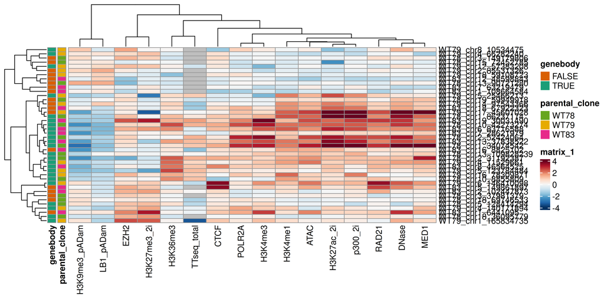

```r
#annotation colors
ann_colors <- list(
  parental_clone = setNames(
    brewer.pal(8, "Dark2")[4:6],
    unique(PB_context_feature_df$parental_clone)
  ),
  genebody = setNames(
    brewer.pal(8, "Dark2")[1:2],
    unique(PB_context_feature_df$genebody)
  )
)

ComplexHeatmap::pheatmap(
  PB_covs_2000_rel_heatmap_matrix,
  scale = "none",                 # IMPORTANT: no additional scaling
  cluster_rows = TRUE,
  cluster_cols = TRUE,
  show_rownames = TRUE,
  show_colnames = TRUE,
  color = colorRampPalette(rev(brewer.pal(n = 11, name="RdBu")))(100),
  breaks = seq(-4, 4, length.out = 101),
  annotation_row = PB_context_feature_df,
  annotation_colors = ann_colors,
  clustering_distance_rows = 'correlation',
  clustering_distance_cols = 'correlation'
  )
```

##heatmap with barplot I want to add a barplot on the side of the heatmap, this cannot easily be done within pheatmap and converting to a real complex heatmap is a mess (because of the NA values). Instead, I will extract the row ordering from the heatmap and make the barplot separately

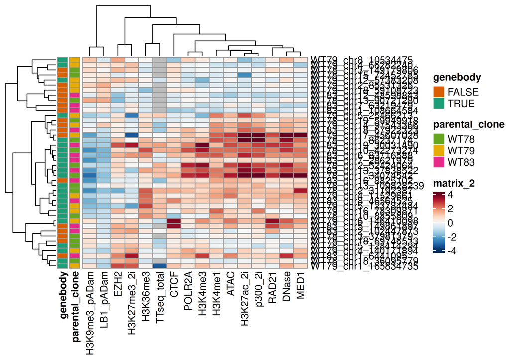

```r
ph = ComplexHeatmap::pheatmap(
  PB_covs_2000_rel_heatmap_matrix,
  scale = "none",                 # IMPORTANT: no additional scaling
  cluster_rows = TRUE,
  cluster_cols = TRUE,
  show_rownames = TRUE,
  show_colnames = TRUE,
  color = colorRampPalette(rev(brewer.pal(n = 11, name="RdBu")))(100),
  breaks = seq(-4, 4, length.out = 101),
  annotation_row = PB_context_feature_df,
  annotation_colors = ann_colors,
  clustering_distance_rows = 'correlation',
  clustering_distance_cols = 'correlation'
  )

ph = ComplexHeatmap::draw(ph)
```

```r
order_of_clones = rownames(PB_covs_2000_rel_heatmap_matrix)[ComplexHeatmap::row_order(ph)]
```

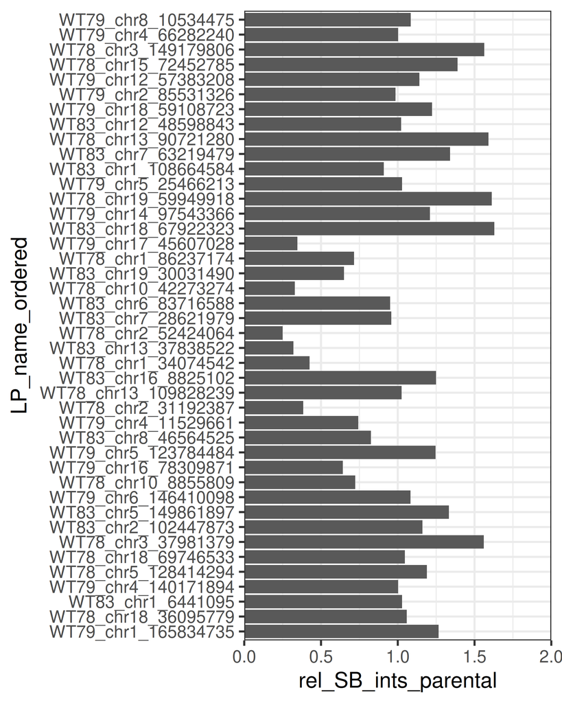

```r
SB_ints_per_PB_comb %>%
  filter(LP_name %in% order_of_clones) %>%
  mutate(LP_name_ordered = factor(LP_name, levels = rev(order_of_clones))) %>%
  ggplot(aes(y = LP_name_ordered, x = rel_SB_ints_parental)) +
  geom_col() +
  scale_y_discrete()+
  scale_x_continuous(limits = c(0,2), expand = c(0,0)) +
  theme_bw()
```

## distribution features genome

Make a supplementary figure panel that shows our integrations are biased towards open chromatin, compared to random genome-wide bins.

Process the background data to get zscores for each background bin

```r
path_context_2000 = '/DATA/shared/projects/local_hopping/hopping_technology/01_genomewide_chromatin_context/CM20260310_local_context/coverage_results/genomewide_background-2000_summary.txt'

#features we want to process
features_oi = c( "'H3K9me3_pADam'",  "'LB1_pADam'" , #heterochromatin
                "'EZH2'", "'H3K27me3-2i'", #polycomb
                "'RAD21'" , "'CTCF'", #3D genome
                "'H3K27ac-2i'", "'p300-2i'", #euchromatin
                "'ATAC'", "'DNase'", #accessibility
                "'H3K36me3'", "'POLR2A'", "'TTseq_fw'", "'TTseq_rv'", #transcription
                "'MED1'", "'H3K4me1'", "'H3K4me3'", #CRE
                "'input_1'", "'input_2'" #input samples
                )

#load the tibbles
context_tib_oi_2000 = read_tsv(path_context_2000) %>%
  dplyr::select(any_of(c("#'chr'","'start'","'end'" , features_oi)))

chrom_background_2000 = chrom_insert_sites(context_tib_oi_2000,
                                   filter(genomic_background_comb, window_size == '2000'), #load properly
                                   blacklist_bed,
                                       log_features = c("LB1_pADam", "H3K9me3_pADam"),
                                       non_cistrome_features = c("TTseq_fw", "TTseq_rv"),
                                       input_cols = c("input_1", "input_2"))
```

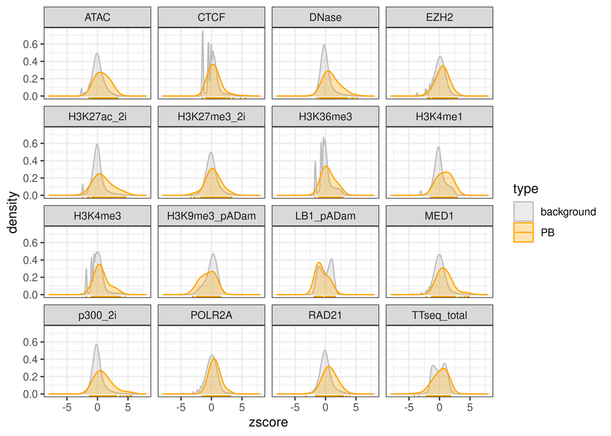

```r
PB_chrom_for_plot = chrom_PB_comb %>%
  mutate(type = "PB") %>%
  filter(removal == 'keep') %>%
  filter(!feature %in% c("TTseq_fw", "TTseq_rv", "input_1", "input_2")) #input is interesting, they overlap nicely, not needed for manuscript fig

colscale_density_plot = scale_colour_manual(values = c(background = 'grey', PB = 'orange'), aesthetics = c('col', 'fill'))

chrom_background_2000 %>%
  mutate(type = 'background') %>%
  bind_rows(PB_chrom_for_plot) %>%
  filter(removal == 'keep') %>%
  filter(!feature %in% c("TTseq_fw", "TTseq_rv", "input_1", "input_2")) %>%
  ggplot(aes(x = zscore, col = type, fill = type)) +
  facet_wrap(~feature) +
  geom_density(adjust = 2, alpha = 0.3) +
  geom_rug(data = PB_chrom_for_plot) +
  theme_bw() +
  scale_x_continuous(limits = c(-8,8)) +
  colscale_density_plot
```

# Correlation chromatin - hop

```r
#get max range of zscores, to use the same plot interval on our other LPs later
PB_context_tib_filt_hopef %>%
  filter(window_size == 2000) %>%
  dplyr::filter(feature %in% relevant_features) %>%
  pull(zscore) %>% summary()
```

```
##    Min. 1st Qu.  Median    Mean 3rd Qu.    Max.    NA's
## -3.3668 -0.3138  0.4389  0.5282  1.2142  5.5867      13
```

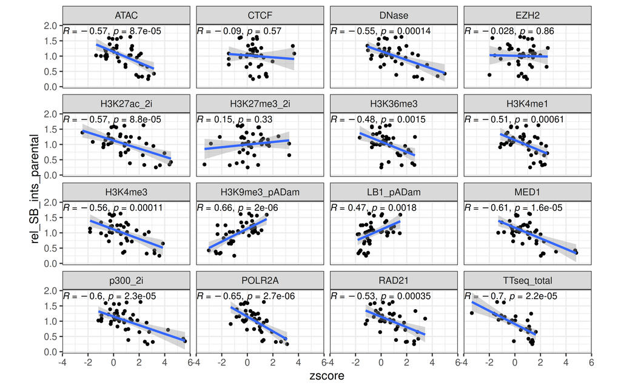

```r
#just one nice plot for supplement
PB_context_tib_filt_hopef %>%
  filter(window_size == 2000) %>%
  dplyr::filter(feature %in% relevant_features) %>%
  ggplot(aes(x = zscore, y = rel_SB_ints_parental)) +
  facet_wrap(~feature) +
  scale_x_continuous(limits = c(-4, 6), expand = c(0,0)) +
  geom_point(size = 1) +
 stat_cor(label.y = 1.8, size =3, method = 'pearson')+
  geom_smooth(method = 'lm')+
  theme_bw() +
  theme(aspect.ratio = 0.5)
```

## Summary correlations

Only for 2kb windows

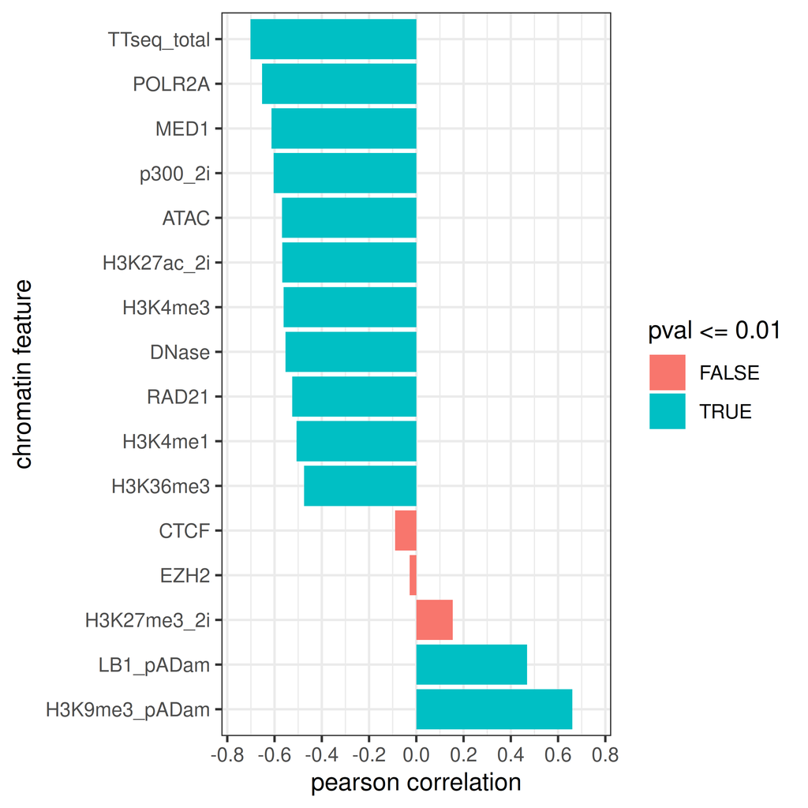

```r
PB_context_2000_tib_filt_hopef = PB_context_tib_filt_hopef %>%
  filter(window_size == 2000) %>%
  dplyr::filter(feature %in% relevant_features)

cor_hop_eff_ls = lapply(relevant_features, function(fi){
  data_feature_oi = filter(PB_context_2000_tib_filt_hopef, feature == fi)
  test = cor.test(data_feature_oi$rel_SB_ints_parental,
                  data_feature_oi$zscore)
  tibble(factor = fi, cor = test$estimate, pval = test$p.value)
})
cor_hop_eff = bind_rows(cor_hop_eff_ls)

cor_hop_eff %>%
  ggplot(aes(x = cor, y = reorder(factor, -cor), fill = pval <= 0.01)) +
  geom_col() +
  scale_x_continuous(limits = c(-0.75, 0.75),
                     breaks = scales::pretty_breaks(n = 6)) +
  theme_bw() +
  xlab('pearson correlation')+
  ylab('chromatin feature')
```

For all window sizes

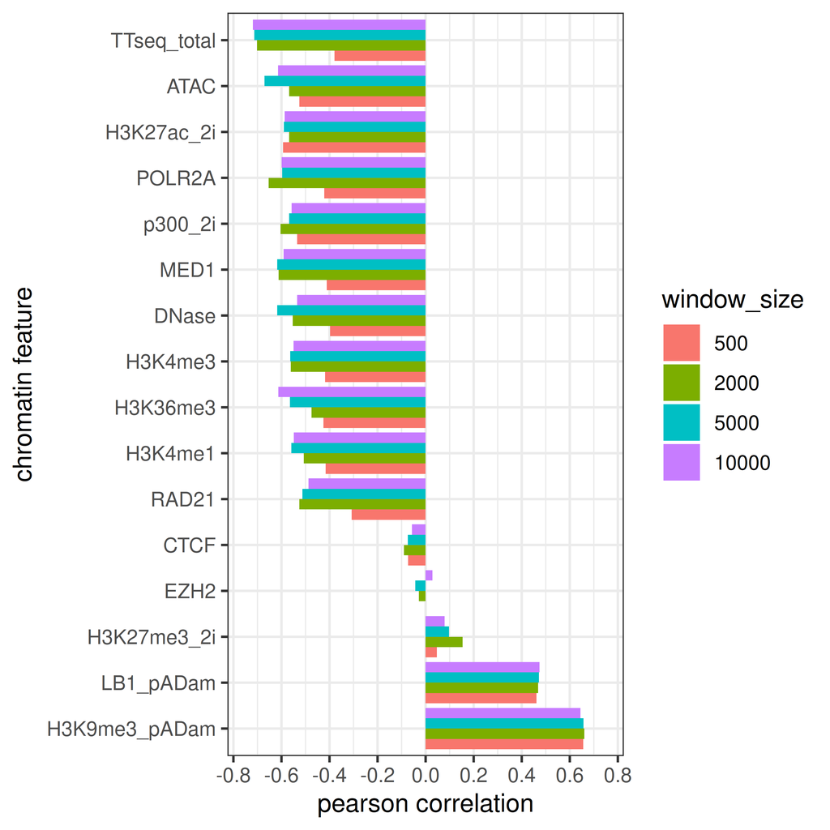

```r
# relevant_features2 = relevant_features[!relevant_features=="TTseq_total"]

cor_hop_eff_ls_ws = lapply(c(500,2000,5000,10000),function(ws){
  lapply(relevant_features, function(fi){

    data_feature_oi = filter(PB_context_tib_filt_hopef, feature == fi &
                               window_size == ws)
    test = cor.test(data_feature_oi$rel_SB_ints_parental,
                    data_feature_oi$zscore)
    tibble(factor = fi, cor = test$estimate, pval = test$p.value, window_size = ws)
  } )
})

cor_hop_eff_ws = bind_rows(bind_rows(cor_hop_eff_ls_ws))

cor_hop_eff_ws %>%
  mutate(window_size = factor(window_size)) %>%
  ggplot(aes(x = cor, y = reorder(factor, -cor), fill = window_size)) +
  geom_col(position = position_dodge()) +
  scale_x_continuous(limits = c(-0.75, 0.75),
                     breaks = scales::pretty_breaks(n = 6)) +
  theme_bw() +
  xlab('pearson correlation')+
  ylab('chromatin feature')
```

Different window sizes are similar, except the 500bp (so 250bp either direct), that is too small to see the effects. Here of course the 10kb window includes the 2kb window as well. But it doesn’t seem like the effect gets diluted / noise gets added, which suggests signals a bit further away from the LP might still influence the hopping.

show significance separately, so I can add it to the plots.

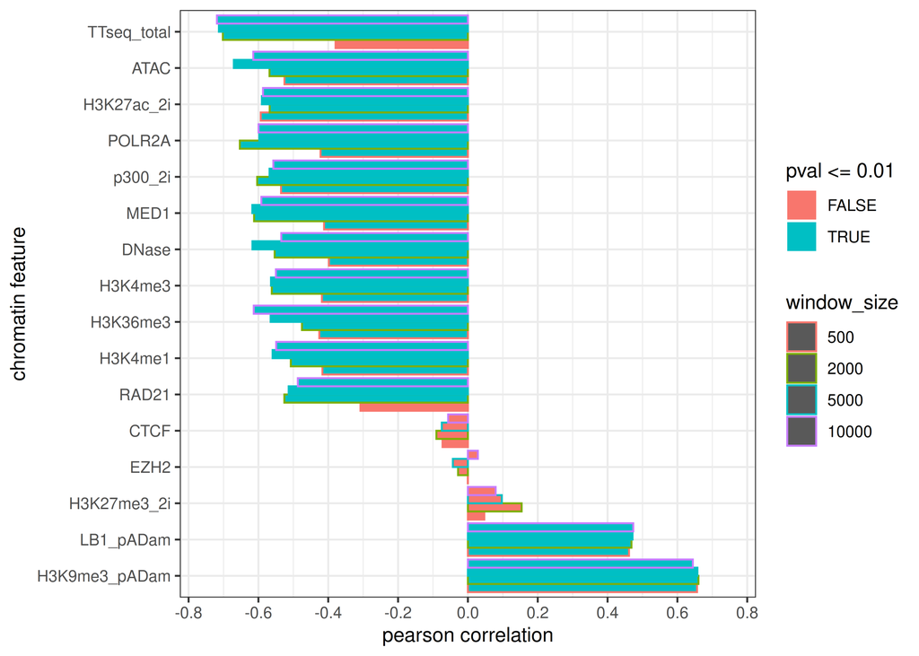

```r
cor_hop_eff_ws %>%
  mutate(window_size = factor(window_size)) %>%
  ggplot(aes(x = cor, y = reorder(factor, -cor), col = window_size, fill = pval<=0.01)) +
  geom_col(position = position_dodge()) +
  scale_x_continuous(limits = c(-0.75, 0.75),
                     breaks = scales::pretty_breaks(n = 6)) +
  theme_bw() +
  xlab('pearson correlation')+
  ylab('chromatin feature')
```

manually combine color for window size and significance in illustrator

## Example correlations

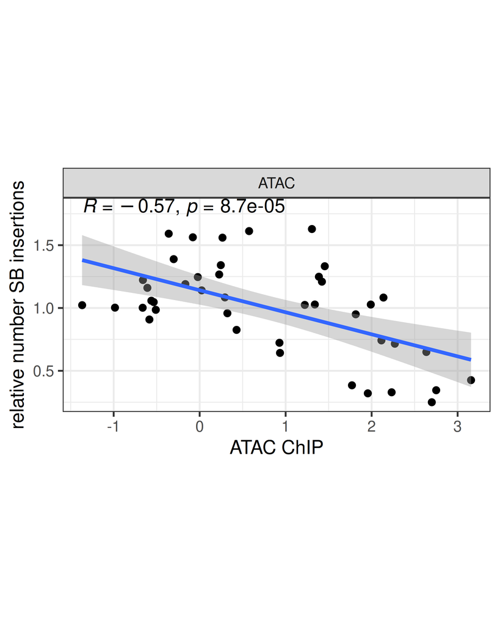

```r
PB_context_tib_filt_hopef %>%
  filter(window_size == 2000) %>%
  dplyr::filter(feature == "ATAC") %>%
  ggplot(aes(x = zscore, y = rel_SB_ints_parental)) +
  facet_wrap(~feature) +
  geom_point() +
 stat_cor(label.y = 1.8)+
  geom_smooth(method = 'lm')+
  theme_bw() +
  xlab("ATAC ChIP") +
  ylab("relative number SB insertions") +
  theme(aspect.ratio = 0.5)
```

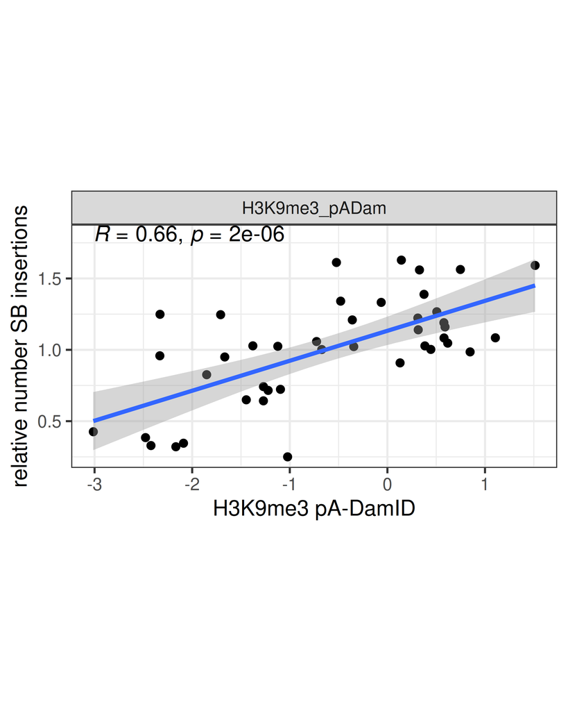

```r
PB_context_tib_filt_hopef %>%
  filter(window_size == 2000) %>%
  dplyr::filter(feature == "H3K9me3_pADam") %>%
  ggplot(aes(x = zscore, y = rel_SB_ints_parental)) +
  facet_wrap(~feature) +
  geom_point() +
 stat_cor(label.y = 1.8)+
  geom_smooth(method = 'lm')+
  theme_bw() +
  xlab("H3K9me3 pA-DamID") +
  ylab("relative number SB insertions")+
  theme(aspect.ratio = 0.5)
```

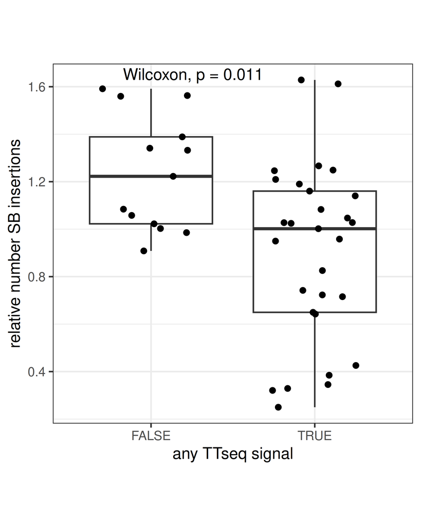

```r
PB_context_tib_filt_hopef %>%
  filter(window_size == 2000) %>%
  dplyr::filter(feature == "TTseq_total") %>%
  mutate(TTseq_signal_present = !is.na(zscore)) %>%
  ggplot(aes(x = TTseq_signal_present, y = rel_SB_ints_parental)) +
    geom_boxplot(outlier.shape = NA) +
  geom_jitter(width = 0.3, height = 0) +
  stat_compare_means()+
  theme_bw() +
  xlab("any TTseq signal") +
  ylab("relative number SB insertions") +
  theme(aspect.ratio = 1)
```

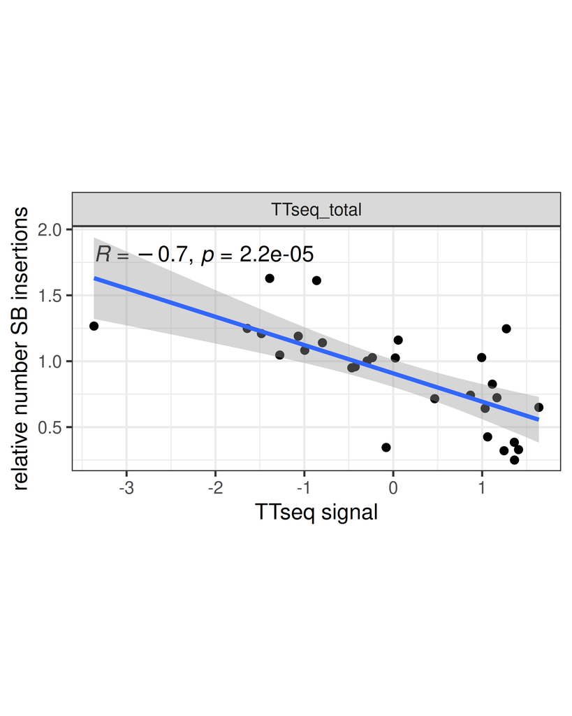

```r
PB_context_tib_filt_hopef %>%
  filter(window_size == 2000) %>%
  dplyr::filter(feature == "TTseq_total" & !is.na(zscore)) %>%
  ggplot(aes(x = zscore, y = rel_SB_ints_parental)) +
  facet_wrap(~feature) +
  geom_point() +
 stat_cor(label.y = 1.8)+
  geom_smooth(method = 'lm')+
  theme_bw() +
  xlab("TTseq signal") +
  ylab("relative number SB insertions")+
  theme(aspect.ratio = 0.5)
```

## Correlation after subsetting

There are two extra correlations we want to show: TTseq and POLR2A after correcting for cCREs

```r
PB_DNase_nearest = read_tsv('/home/c.moene/projects/hopping_technology/SB_transposition_manuscript/Chromatin_context/CM20260310_local_context/feature_results/nearest_Omar_PB_DNase.txt',
                          col_names = c('chr_PB', 'start_PB', 'end_PB', 'LP_name', 'chr_peak', 'start_peak', 'end_peak',paste0("X", 8:10), 'score',paste0("X", 12:14), "distance"))

PB_DNase_nearest_forjoin = PB_DNase_nearest %>%
  dplyr::select(LP_name, chr_peak, distance) %>%
  dplyr::rename(distance_to_peak = distance) %>%
  distinct()

PB_context_feature_tib_DNase = PB_context_tib_filt_hopef %>%
  filter(window_size == 2000) %>%
  select(LP_nr, LP_name, chr, start_interval, end_interval, parental_clone) %>%
  distinct() %>%
  left_join(PB_DNase_nearest_forjoin) %>%
  mutate(DNase_peak = distance_to_peak < 2000) #NB this is a bigger window than the ChIP bw quantification
```

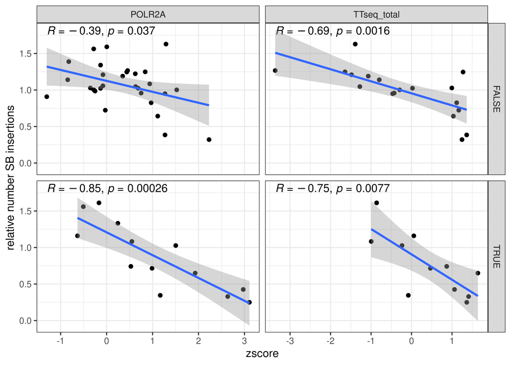

```r
PB_context_tib_filt_hopef %>%
  filter(window_size == 2000) %>%
  dplyr::filter(feature %in% c("TTseq_total", "POLR2A")) %>%
  left_join(PB_context_feature_tib_DNase) %>%
  ggplot(aes(x = zscore, y = rel_SB_ints_parental)) +
  facet_grid(DNase_peak ~ feature, scales = 'free_x') +
  geom_point() +
  stat_cor( label.y = 1.8)+
  geom_smooth(method = 'lm')+
  theme_bw() +
  ylab("relative number SB insertions")
```

check the high TTseq, no DNase integrations